# Statistical Analysis for Functional Health Literacy on Treatment Adherence among Type 2 Diabetic Clients’ Survey Data

Alfeo Sabay

2020-01-13

## Data Description

Survey data was gathered using two tools from 276 Diabetic Clients. The NVS (Newest Vital Sign) tool produced a literacy score ranging from zero to six (0 with the lowest literacy to 6 with the highest literacy) from a series of survey questions presented to the Diabetic Client. Similarly, the BMQ (Brief Medical Questionaire) tool derived a score in the range of zero to eleven (0 as most adherent and 11 as least adherent) relfecting the patient’s adherence to treatment from a questionaire.

This survey includes Demographic data. Age, Other Medications and Gender. Age is the disclosed age of the subject. Other Medications (coded as yes/no) reflect whether or not the subject is currently taking other medications apart from the diabetic medication. Gender (coded as Male, Female) reflect the gender of the subject.

In order to examine the possible effects of variables that impact adherence, Logistic Regression will be performed on the data set. As such, the reponse variable BMQ has been coded as “Adherent” for scores of zero and “Non-Adherent” for scores greater than zero. Similarly, a new independent variable (ordinal categorical) was derived from the NVS Scores to reflect 3 literacy levels (“limited”, “possibly”, “adequate”). NVS scores of 0-1 is coded as “limited” literacy level. NVS scores of 2-3 are coded as “possibly” literacy level. NVS scores of 4-6 are coded as “adequate” literacy level.

Table continues below

| NVS | Regimen | Belief | Recall | Access | BMQ | Gender | Age |
| --- | --- | --- | --- | --- | --- | --- | --- |
| 2 | 1 | 0 | 0 | 0 | Non-Adherent | Male | 45 |
| 6 | 0 | 0 | 1 | 1 | Non-Adherent | Female | 47 |
| 4 | 0 | 0 | 1 | 1 | Non-Adherent | Male | 47 |
| 1 | 0 | 0 | 0 | 0 | Adherent | Male | 78 |
| 0 | 0 | 0 | 0 | 0 | Adherent | Female | 67 |
| 1 | 0 | 0 | 0 | 0 | Adherent | Female | 56 |

| Other_Medications | Literacy_level |
| --- | --- |
| yes | possibly |
| no | adequate |
| yes | adequate |
| yes | limited |
| yes | limited |
| yes | limited |

**Table 1: Data Sample from Dataset**

Table continues below

| NVS | Regimen | Belief | Recall |
| --- | --- | --- | --- |
| Min. :0.000 | Min. :0.0000 | Min. :0.0000 | Min. :0.0000 |
| 1st Qu.:2.000 | 1st Qu.:0.0000 | 1st Qu.:0.0000 | 1st Qu.:0.0000 |
| Median :3.000 | Median :0.0000 | Median :0.0000 | Median :0.0000 |
| Mean :3.315 | Mean :0.4239 | Mean :0.1413 | Mean :0.4891 |
| 3rd Qu.:5.000 | 3rd Qu.:1.0000 | 3rd Qu.:0.0000 | 3rd Qu.:1.0000 |
| Max. :6.000 | Max. :1.0000 | Max. :1.0000 | Max. :1.0000 |

Table continues below

| Access | BMQ | Gender | Age |
| --- | --- | --- | --- |
| Min. :0.0000 | Adherent : 84 | Female:165 | Min. :37.00 |
| 1st Qu.:0.0000 | Non-Adherent:192 | Male :111 | 1st Qu.:51.00 |
| Median :0.0000 | NA | NA | Median :58.00 |
| Mean :0.4239 | NA | NA | Mean :58.55 |
| 3rd Qu.:1.0000 | NA | NA | 3rd Qu.:67.00 |
| Max. :1.0000 | NA | NA | Max. :82.00 |

| Other_Medications | Literacy_level |
| --- | --- |
| no : 77 | limited : 51 |
| yes:199 | possibly: 96 |
| NA | adequate:129 |
| NA | NA |
| NA | NA |
| NA | NA |

**Table 2: Statistical Summary**

## Descriptive Statistics

Plots are shown below for initial exploration of the data.

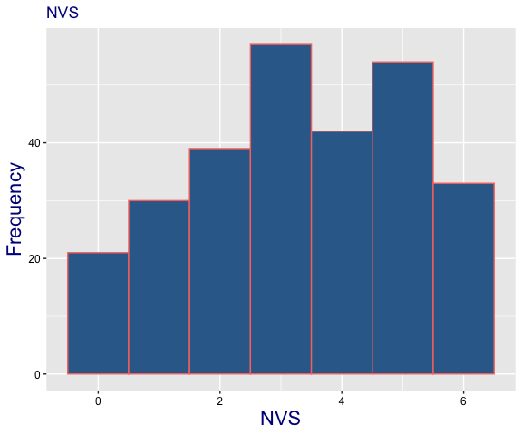

| NVS | n |
| --- | --- |
| 0 | 21 |
| 1 | 30 |
| 2 | 39 |
| 3 | 57 |
| 4 | 42 |
| 5 | 54 |
| 6 | 33 |

**Figure 1: NVS - Literacy Distribution**

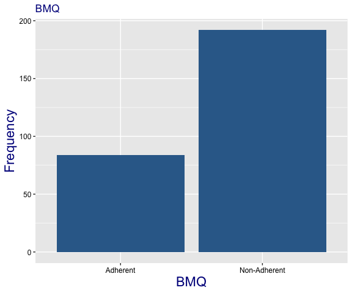

| BMQ | n |
| --- | --- |
| Adherent | 84 |
| Non-Adherent | 192 |

**Figure 2: BMQ - Overall Distribution**

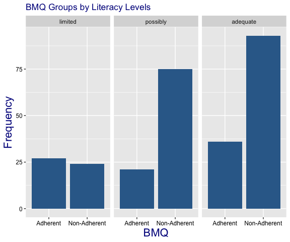

| Literacy_level | BMQ | n |
| --- | --- | --- |
| limited | Adherent | 27 |
| limited | Non-Adherent | 24 |
| possibly | Adherent | 21 |
| possibly | Non-Adherent | 75 |
| adequate | Adherent | 36 |
| adequate | Non-Adherent | 93 |

**Figure 3: BMQ - By Literacy Groups**

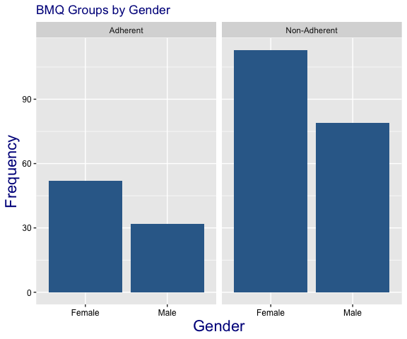

| BMQ | Gender | n |
| --- | --- | --- |
| Adherent | Female | 52 |
| Adherent | Male | 32 |
| Non-Adherent | Female | 113 |
| Non-Adherent | Male | 79 |

**Figure 4: BMQ - By Gender**

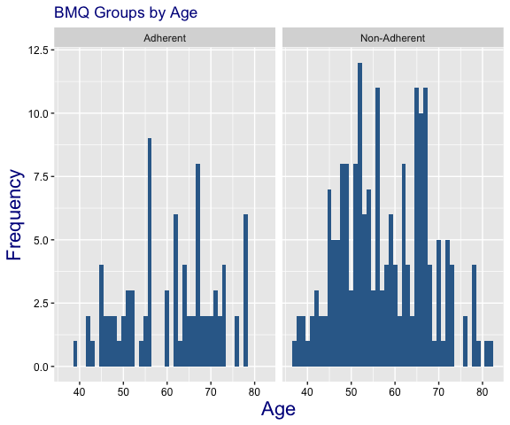

| BMQ | Age |
| --- | --- |
| Adherent :84 | Min. :39.00 |
| Non-Adherent: 0 | 1st Qu.:52.00 |
| NA | Median :62.00 |
| NA | Mean :60.79 |
| NA | 3rd Qu.:68.25 |
| NA | Max. :78.00 |

| BMQ | Age |
| --- | --- |
| Adherent : 0 | Min. :37.00 |
| Non-Adherent:192 | 1st Qu.:49.75 |
| NA | Median :56.00 |
| NA | Mean :57.58 |
| NA | 3rd Qu.:66.00 |
| NA | Max. :82.00 |

**Figure 5: BMQ - By Age**

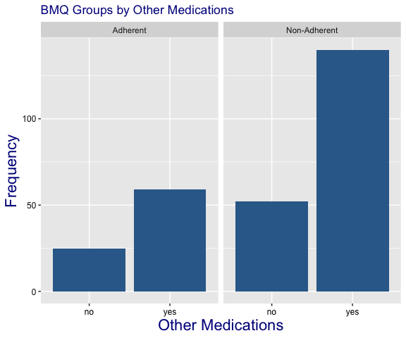

| BMQ | Other_Medications | n |
| --- | --- | --- |
| Adherent | no | 25 |
| Adherent | yes | 59 |
| Non-Adherent | no | 52 |
| Non-Adherent | yes | 140 |

**Figure 6: BMQ - By Other Medications**

#### Chi-square Test For Independence (Null Hypothesis: Adherence and Literacy are Independent)

The small p-value (0.0003503) in the Chi-square test output below means we reject the null hypothesis that BMQ and Literacy_level are independent of each other and we accept the alternative hypothesis that there is a relation between BMQ and Literacy_level.

| Test statistic | df | P value |
| --- | --- | --- |
| 15.91 | 2 | 0.0003503 * * * |

Table: Pearson’s Chi-squared test: `v_table`

**Table 3: Chi-Square Test for Adherence and Literacy**

## Logistic Regression

We first start with a full Logistic Regression Model.

**BMQ = Literacy_level + Gender + Age + Other_Medications**

|  | Estimate | Std. Error | z value | Pr(>\|z\|) |
| --- | --- | --- | --- | --- |
| **(Intercept)** | 2.611 | 0.849 | 3.075 | 0.002103 |
| **Literacy_level.L** | 0.7967 | 0.2474 | 3.221 | 0.001278 |
| **Literacy_level.Q** | -0.7242 | 0.2497 | -2.901 | 0.003723 |
| **GenderMale** | 0.1287 | 0.2804 | 0.4591 | 0.6461 |
| **Age** | -0.03441 | 0.01343 | -2.563 | 0.01037 |
| **Other_Medicationsyes** | 0.0962 | 0.3013 | 0.3193 | 0.7495 |

Table: Fitting generalized (binomial/logit) linear model: BMQ ~ Literacy_level + Gender + Age + Other_Medications

**Table 4: Full Model Logistic Regression**

As can be seen from the results of the Logistic Regression above, the p-values for the variables Other_medications (0.7495) and Gender (0.6461) are large meaning these two variables do not contribute significantly to the response variable BMQ.

As such, we can build a simpler model without Gender and Other_medications.

**BMQ = Literacy_level + Age**

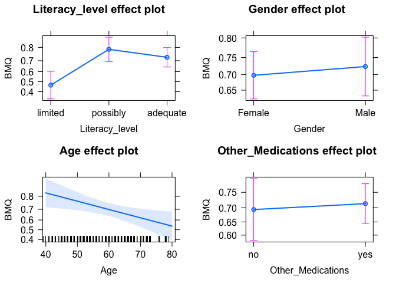

**Figure 7: Full Model Effects Plot**

As can be seen, the p-values in the reduced model are below the significance level of .05 therefore Literacy_level and Age can be chosen as the predictors.

|  | Estimate | Std. Error | z value | Pr(>\|z\|) |
| --- | --- | --- | --- | --- |
| **(Intercept)** | 2.73 | 0.8113 | 3.365 | 0.0007646 |
| **Literacy_level.L** | 0.7918 | 0.2469 | 3.207 | 0.001342 |
| **Literacy_level.Q** | -0.7348 | 0.2488 | -2.953 | 0.003149 |
| **Age** | -0.03439 | 0.01342 | -2.563 | 0.01039 |

Table: Fitting generalized (binomial/logit) linear model: BMQ ~ Literacy_level + Age

**Table 5: Reduced Model Logistic Regression**

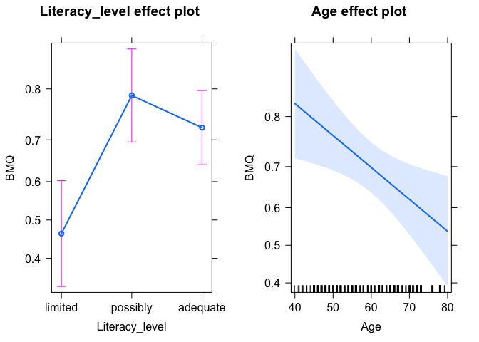

**Figure 8: Reduced Model Effects Plot**

Since the reduced model is a subset of the full model, we can perform ANOVA (Analysis of Variance) on the two models to see if they perform the same.

| Resid. Df | Resid. Dev | Df | Deviance | Pr(>Chi) |
| --- | --- | --- | --- | --- |
| 272 | 317.3959 | NA | NA | NA |
| 270 | 317.0817 | 2 | 0.3141375 | 0.8546453 |

**Table 6: ANOVA: Full and Reduced Model Comparison**

With a p-value of 0.85, we can conclude that the reduced model performs just as well as the full model therefore we will use the reduced model going forward.

**Model Coefficients**

The coefficients of the fitted model gives us information on the predictor’s effect on the response variable BMQ. The values below have been converted to Odds Scale.

The table 7 below shows the coefficients for the reduced BMQ model. Literacy_level.L is the linear coefficient while Literacy_level.Q is the quadratic coefficient. For our purposes, the value of interest is Literacy_level.L. Here it simply means that for every increment of Literacy_level, the effect of BMQ is multiplied 2.207 times and .966 times every increment in Age.

Table 8 shows these model coefficients with confidence interval of 95%.

| (Intercept) | Literacy_level.L | Literacy_level.Q | Age |
| --- | --- | --- | --- |
| 15.34 | 2.207 | 0.4796 | 0.9662 |

**Table 7: Model Coefficients (Odds Scale)**

|  | 2.5 % | 97.5 % |
| --- | --- | --- |
| **(Intercept)** | 3.214 | 78.04 |
| **Literacy_level.L** | 1.365 | 3.605 |
| **Literacy_level.Q** | 0.2904 | 0.7728 |
| **Age** | 0.9407 | 0.9917 |

**Table 8: Model Coefficients with 95% Confidence Intervals**

**Examining The Effects of Literacy_level and Age (Table 9)**  
With the fitted BMQ model, we can examine the effect (probability) of each predictor variable by performing a model predict using test data. In this test, we plug in 3 levels of literacy (“limited”, “possibly”, “adequate”) while holding age constant (mean value of Age).

| Literacy_level | Age | prob | Pred |
| --- | --- | --- | --- |
| limited | 58.55 | 0.4642 | Non-Adherent |
| possibly | 58.55 | 0.7886 | Adherent |
| adequate | 58.55 | 0.7264 | Adherent |

**Table 9: Fitted Model Prediction Age Constant**

| Literacy_level | Age | prob | Pred |
| --- | --- | --- | --- |
| limited | 40 | 0.6212 | Adherent |
| limited | 50 | 0.5376 | Adherent |
| limited | 60 | 0.4519 | Non-Adherent |
| limited | 70 | 0.3689 | Non-Adherent |
| limited | 80 | 0.293 | Non-Adherent |

**Table 10: Fitted Model Prediction Holding Literacy Level At Limited**

| Literacy_level | Age | prob | Pred |
| --- | --- | --- | --- |
| possibly | 40 | 0.8759 | Adherent |
| possibly | 50 | 0.8335 | Adherent |
| possibly | 60 | 0.7802 | Adherent |
| possibly | 70 | 0.7156 | Adherent |
| possibly | 80 | 0.6408 | Adherent |

**Table 11: Fitted Model Prediction Holding Literacy Level At Possibly**

| Literacy_level | Age | Prob | Pred |
| --- | --- | --- | --- |
| adequate | 40 | 0.834 | Adherent |
| adequate | 50 | 0.7808 | Adherent |
| adequate | 60 | 0.7164 | Adherent |
| adequate | 70 | 0.6417 | Adherent |
| adequate | 80 | 0.5594 | Adherent |

**Table 12: Fitted Model Prediction Holding Literacy Level At Adequate**

## Post Hoc Power Analysis

Based on a similar study by Olaolournpo O, et. al. 2018, at the start of the study, the sample size was calculated using a Test For Proportions Power Analysis. This resulted in a minimum sample size of 242 subjects given two proportions of .33 (Adequate Literacy, Non-Adherent) and .55 (Limited Literacy, Adherence) with desired Power of .8 at a Significance Level of .05. Based on this sample calculation, the team gathered survey data for **276** subjects.

Later in this study a deeper statistical analysis using Logistic Regression was necessary in order to get a better understanding of the predictor effects on the response variable (BMQ) which represents the patient’s adherence. The minimum sample size calculation for Logistic Regression (General Linear Model) differs from that of Test for Proportions as previously calculated thus we recalculated the minimum sample size in order to insure proper sample representation for the Power (.8) desired at a Significance Level of .05.

**General Linear Model Sample Size Calculation**

f2 = (R1 - R2)/1-R1 - the effect size

f2 = (.55-.33)/(1-.55) = .48

u = Number of Predictors (4)

sig.level = .05

power = .8

Plugging in these values to the pwr.f2.test function (R), results in the following:  
**pwr.f2.test(u=4, f2=.48, sig.level = .05, power=.8)**

- **u**: *4*
- **v**: *25.01*
- **f2**: *0.48*
- **sig.level**: *0.05*
- **power**: *0.8*
- **method**: Multiple regression power calculation

The output v is the denominator degrees of freedom. The formula for v is:  
**N - u - 1 = v**  
Calculating for N (sample size for Logistic Regression Model)  
**N = 25 + 4 + 1 = 30**  
This is the minimum sample size required for the above Logistic Regression. As such the sample size of 276 from the dataset is more than adequate and therefore can only increase the Power of the Prediction Probabilities in this regression.

The plot below demonstrates how Power varies with respect to sample size. The power required in this study is .8 with a calculated minimum sample size of 30.

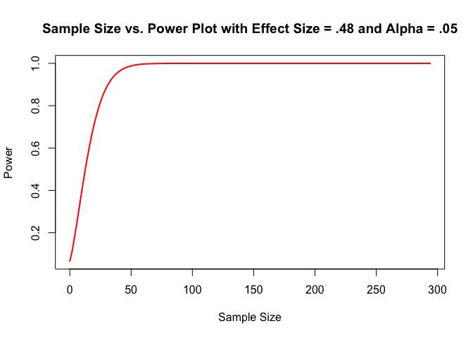